# individual1

Danny Nguyen

February 5, 2019

## R Markdown

1. How are ratings distributed? Draw a histogram of ratings and describe it. Don’t forget to mention outliers, if there are any.

Based on the image of the histogram, there is sort of an outlier right by the number 5 rating. If the outlier were not there, the graph could potentially be considered left-skewed. However, with the outlier, the graph displays a large amount of ratings located around the number 3 rating.

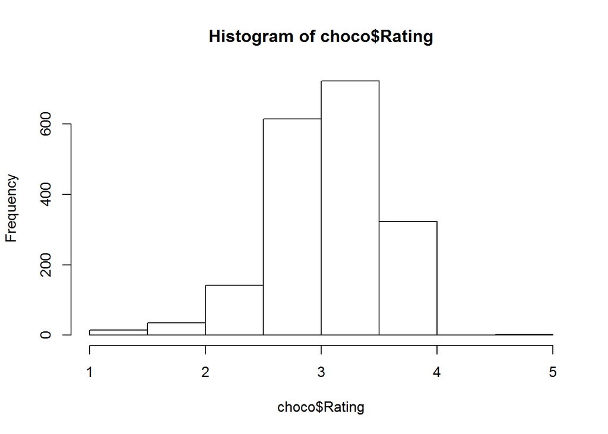

```r
choco <- read.csv("https://xdaiisu.github.io/ds202materials/hwlabs/choco.csv")
hist(choco$Rating)
```

2. Do ratings depend on the cacao percentage of a chocolate bar?

Based on the following graph, it seems that ratings do not really depend on the cacao percentage of a chocolate bar. Most ratings located around the same percentage seem to span across the entire rating scale. For example, the 70 percent area has ratings for the integers from 1 through 5. Another example for a specific rating, rating number 3 has a lot of ratings with percentages ranging from 50 to 100. Therefore, it could be a relatively safe assumption that ratings do not really depend on the cacao percentage of a chocolate bar.

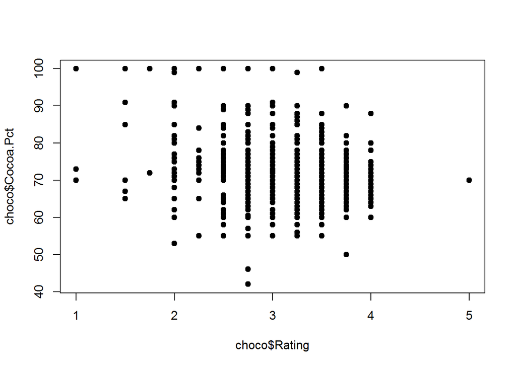

```r
plot(choco$Rating, choco$Cocoa.Pct, pch=19)
```